# Prior distributions and uncertainty

Peter Ralph

5 November – Advanced Biological Statistics

# Biased coins

## a motivating example

Suppose I have two trick coins:

- one (coin A) comes up heads 75% of the time, and
- the other (coin B) only 25% of the time.

But, I lost one and I don’t know which! So, I flip it **10 times** and get **6 heads**. *Which is it, and how sure are you?*

## Possible answers:

1. Er, probably coin (A)?
2. Well,
   $$\begin{aligned}
   \P\{ \text{6 H in 10 flips} \given \text{coin A} \}
   &= \binom{10}{6} (.75)^6 (.25)^4 \\
   &= 0.146
   \end{aligned}$$
   and
   $$\begin{aligned}
   \P\{ \text{6 H in 10 flips} \given \text{coin B} \}
   &= \binom{10}{6} (.25)^6 (.75)^4 \\
   &= 0.016
   \end{aligned}$$
   … so, probably coin (A)?

For a precise answer…

3. *Before flipping*, each coin seems equally likely. Then

   $$\begin{aligned}
   \P\{ \text{coin A} \given \text{6 H in 10 flips} \}
   &= \frac{
   \frac{1}{2} \times 0.146
   }{
   \frac{1}{2} \times 0.146
   +
   \frac{1}{2} \times 0.016
   } \\
   &= 0.9
   \end{aligned}$$

# Probability: review and notation

## Probability rules:

0. *Probabilities are proportions:* $\hspace{2em} 0 \le \P\{A\} \le 1$
1. *Everything:* $\hspace{2em} \P\{ \Omega \} = 1$
2. *Complements:* $\hspace{2em} \P\{ \text{not } A\} = 1 - \P\{A\}$
3. *Disjoint events:* If $\hspace{2em} \P\{A \text{ and } B\} = 0$ then $\hspace{2em} \P\{A \text{ or } B\} = \P\{A\} + \P\{B\}$.
4. *Independence:* $A$ and $B$ are independent iff $\P\{A \text{ and } B\} = \P\{A\} \P\{B\}$.
5. *Conditional probability:*
   $$\P\{A \given B\} = \frac{\P\{A \text{ and } B\}}{ \P\{B\} }$$

## Bayes’ rule

A consequence is

$$\P\{B \given A\} = \frac{\P\{B\} \P\{A \given B\}}{ \P\{A\} } .$$

In “Bayesian statistics”:

- $B$: possible model
- $A$: data
- $\P\{B\}$: prior weight on model $B$
- $\P\{A \given B\}$: likelihood of data under $B$
- $\P\{B\} \P\{A \given B\}$: posterior weight on $B$
- $\P\{A\}$: total sum of posterior weights

## Bayes’ rule: for coins (in class)

A consequence is

$$\P\{B \given A\} = \frac{\P\{B\} \P\{A \given B\}}{ \P\{A\} } .$$

In our coin example

- $B$: possible model (*I have the 75% coin*)
- $A$: data (*6 Heads out of 10 flips*)
- $\P\{B\}$: prior weight on model $B$ (*how likely I think it is I got the 75% coin*)
- $\P\{A \given B\}$: likelihood of data under $B$ (*chance of getting 6 H with 10 flips with the 75% coin*)
- $\P\{B\} \P\{A \given B\}$: posterior weight on $B$ (*combined probabilityof getting 75% coin and then getting 6 H out of 10 flips*)
- $\P\{A\}$: total sum of posterior weights (*the sum of the last thing over all possible coins*)

# Breaking it down with more coins

Suppose instead I had 9 coins, with probabilities 10%, 20%, …, 90%; as before I flipped one 10 times and got 6 heads. For each $\theta$ in $0.1, 0.2, \ldots, 0.8, 0.9,$ find
$$\begin{aligned}
\P\{\text{ coin has prob $\theta$ } \given \text{ 6 H in 10 flips } \} .
\end{aligned}$$

*Question:* which coin(s) is it, and how sure are we? (And, what does it mean when we say how sure we are?)

## Uniform prior

prior

$\times$

likelihood

$\propto$

posterior

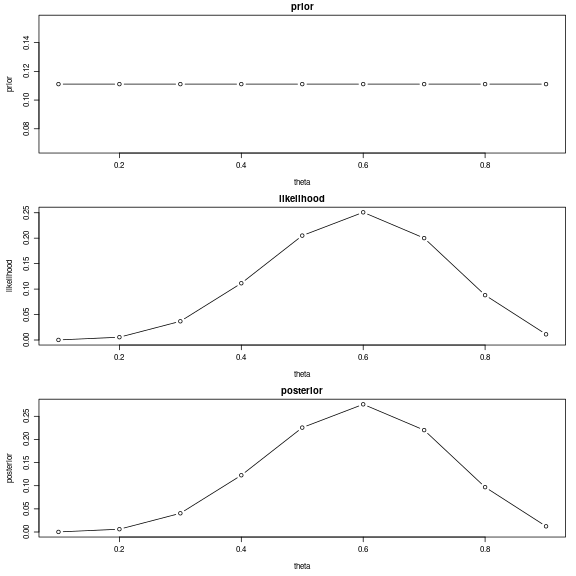

## Weak prior

prior

$\times$

likelihood

$\propto$

posterior

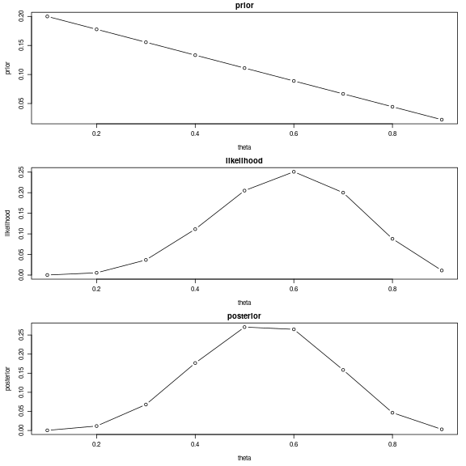

## Strong prior

prior

$\times$

likelihood

$\propto$

posterior

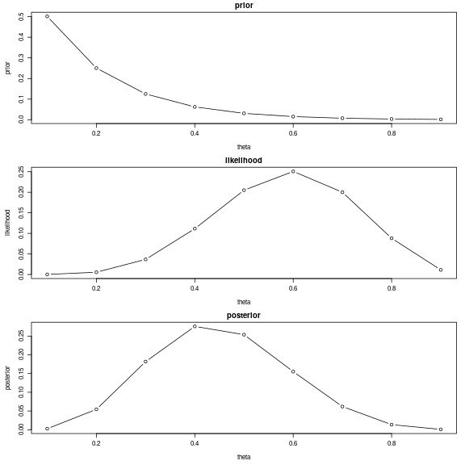

## The likelihood: 6 H in 10 flips

prior

$\times$

likelihood

$\propto$

posterior

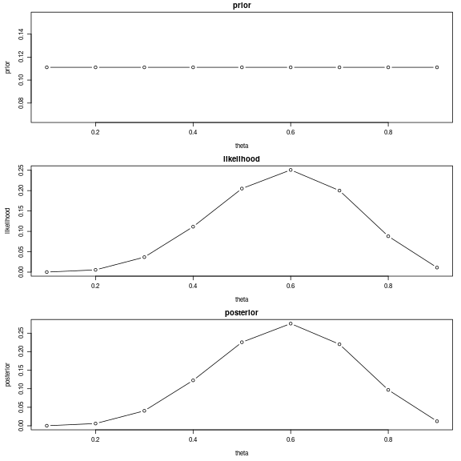

## The likelihood: 30 H in 50 flips

prior

$\times$

likelihood

$\propto$

posterior

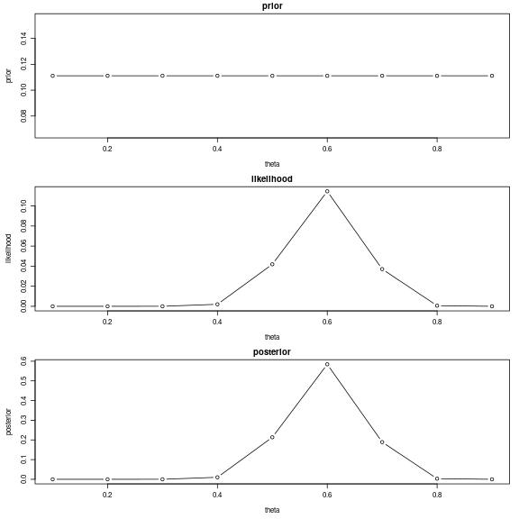

## The likelihood: 60 H in 100 flips

prior

$\times$

likelihood

$\propto$

posterior

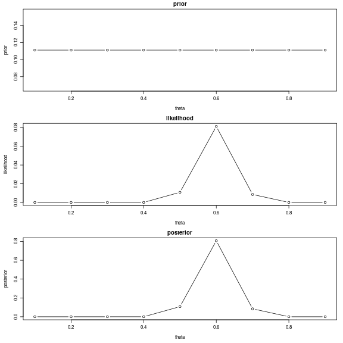

## The likelihood: 6,000 H in 10,000 flips

prior

$\times$

likelihood

$\propto$

posterior

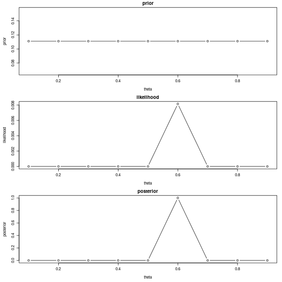

# A question

## What is the right answer to the “coin question”?

Recall: there were nine possible values of $\theta$.

Which coin is it, and how sure are you?

*Possible types of answer:*

1. “best guess”
2. “range of values”
3. “don’t know”

Give examples of when each type of answer is the right one.

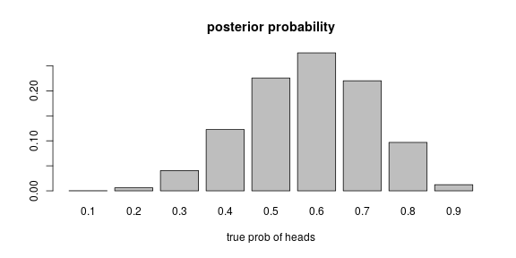

```r
theta <- (1:9)/10
prior <- rep(1/9, 9)
likelihood <- dbinom(6, size=10, prob=theta)
posterior <- prior*likelihood/sum(prior*likelihood)
names(posterior) <- theta
barplot(posterior, xlab='true prob of heads', main='posterior probability')
```

# Stochastic Minute

## The Beta Distribution

If
$$P \sim \text{Beta}(a,b)$$
then $P$ has *probability density*
$$p(\theta) = \frac{ \theta^{a-1} (1 - \theta)^{b-1} }{ B(a,b) } .$$

- Takes values between 0 and 1.
- If $U_{(1)} < U_{(2)} < \cdots < U_{(n)}$ are sorted, independent $\text{Unif}[0,1]$ then $U_{(k)} \sim \text{Beta}(k, n-k+1)$.
- Mean: $a/(a+b)$.
- Larger $a+b$ is more tightly concentrated (like $1/\sqrt{a+b}$)

## Exercise

In pairs, *simulate*:

1. One thousand “random coins” whose probabilities are drawn from a $\Beta(5,5)$ distribution. (`rbeta()`) Make a histogram of these probabilities.
2. Flip each coin ten times and record the number of heads. (`rbinom()`)
3. Make a histogram of the *probabilities* of those coins that got exactly 3 heads, and compare to the first histogram.

# Unknown coins

## Motivating example

Now suppose we want to estimate the probability of heads for a coin *without* knowing the possible values. (or, a disease incidence, or error rate in an experiment, …)

We flip it $n$ times and get $z$ Heads.

The *likelihood* of this, given the prob-of-heads $\theta$, is:
$$p(z \given \theta) = \binom{n}{z}\theta^z (1-\theta)^{n-z} .$$

How to weight the possible $\theta$? Need a flexible set of weighting functions, i.e., **prior distributions** on $[0,1]$.

- **Beta** distributions.

What would we use if:

- the coin is probably close to fair.
- the disease is probably quite rare.
- no idea whatsoever.

## Beta-Binomial Bayesian analysis

If
$$\begin{aligned}
P &\sim \text{Beta}(a,b) \\
Z &\sim \text{Binom}(n,P) ,
\end{aligned}$$
then by Bayes’ rule:
$$\begin{aligned}
\P\{ P = \theta \given Z = z\}
&=
\frac{\P\{Z = z \given P = \theta \} \P\{P = \theta\}}{\P\{Z = z\}} \\
&=
\frac{
\binom{n}{z}\theta^z (1-\theta)^{n-z}
\times
\frac{\theta^{a-1}(1-\theta)^{b-1}}{B(a,b)}
}{
\text{(something)}
} \\
&=
\text{(something else)} \times \theta^{a + z - 1} (1-\theta)^{b + n - z - 1} .
\end{aligned}$$

“Miraculously” *(the Beta is the conjugate prior for the Binomial)*,
$$\begin{aligned}
(P \given Z = z) \sim \text{Beta}(a+z, b+n-z) .
\end{aligned}$$

## Discuss/demonstration:

We flip an odd-looking coin 100 times, and get 65 heads. What is it’s true* probability of heads?

1. True = ??
2. What prior to use?
3. Is it reasonable that $\theta = 1/2$?
4. Best guess at $\theta$?
5. How far off are we, probably?

# Reporting uncertainty

## How do we communicate results?

If we want a *point estimate*:

1. posterior mean,
2. posterior median, or
3. maximum *a posteriori* estimate (“MAP”: highest posterior density).

These all convey “where the posterior distribution is”, more or less.

What about uncertainty?

## Credible region

**Definition:** A 95% *credible region* is a portion of parameter space having a total of 95% of the *posterior probability*.

(same with other numbers for “95%”)

## Interpretation #1

If we construct a 95% credible interval for $\theta$ for each of many datasets; *and* the coin in each dataset has $\theta$ drawn independently from the prior, *then* the true $\theta$ will fall in its credible interval for 95% of the datasets.

## Interpretation #2

If we construct a 95% credible interval for $\theta$ with a dataset, and the distribution of the coin’s true $\theta$ across many parallel universes is given by the prior, then the true $\theta$ will be in the credible interval in 95% of those universes.

## Interpretation #3

Given my prior beliefs (prior distribution), the posterior distribution is the most rational${}^*$ way to update my beliefs to account for the data.

${}^*$ if you do this many times you will be wrong least often

${}^*$ **or** you will be wrong in the fewest possible universes

## But which credible interval?

**Definition:** The “95% highest density interval” is the 95% credible interval with the highest posterior probability density at each point.

((back to the simple example))

# Hierarchical coins

## Motivating problem: more coins

Suppose now we have data from $n$ different coins from the same source. We don’t assume they have the *same* $\theta$, but don’t know what it’s distribution is, so try to *learn* it.

$$\begin{aligned}
Z_i &\sim \Binom(N_i, \theta_i) \\
\theta_i &\sim \Beta(\text{mode}=\omega, \text{conc}=\kappa) \\
\omega & = ? \\
\kappa & = ?
\end{aligned}$$

*note:* The “mode” and “concentration” are related to the shape parameters by: $\alpha = \omega (\kappa - 2) + 1$ and $\beta = (1 - \omega) (\kappa - 2) + 1$.

## Binomial versus Beta-Binomial

What is different between:

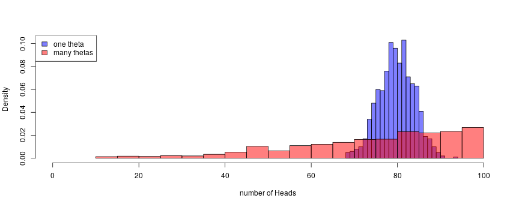

```r
ncoins <- 1000
nflips <- 100
theta1 <- rbeta(1,3,1)
binom_Z <- rbinom(ncoins, size=nflips, prob=theta1)
theta2 <- rbeta(ncoins,3,1)
bb_Z <- rbinom(ncoins, size=nflips, prob=theta2)
hist(binom_Z, breaks=30, col=adjustcolor("blue", 0.5), main='', xlim=c(0,nflips), freq=FALSE, xlab='number of Heads')
hist(bb_Z, breaks=30, col=adjustcolor("red", 0.5), add=TRUE, freq=FALSE)
legend("topleft", fill=adjustcolor(c('blue', 'red'), 0.5), legend=c('one theta', 'many thetas'))
```

# MC Stan

## Stan

Stanislaw Ulam

## The skeletal Stan program

```
data {
    // stuff you input
}
transformed data {
    // stuff that's calculated from the data (just once, at the start)
}
parameters {
    // stuff you want to learn about
}
transformed parameters {
    // stuff that's calculated from the parameters (at every step)
}
model {
    // the action!
}
generated quantities {
    // stuff you want computed also along the way
}
```